# Activity Classification

Ian Meikle

21 March 2015

# Objective

One thing that people regularly do is quantify how much of a particular activity they do, but they rarely quantify how well they do it. Data was collected from accelerometers on the belt, forearm, arm, and dumbell of 6 participants. They were asked to perform barbell lifts correctly and incorrectly in 5 different ways. The objective of this study is to see if the data collected can be used to determine whether or not an exercise was performed correctly.

# Data

The data was provided in two sets: training and test. The training set consisted of 19622 observations of 160 variables. The test set was much smaller, 20 observations of 160 variables. The outcome ‘classe’ was present in the training data set, but was replaced by a placeholder variable in the test set. Validation of the model was only possible by submission of predictions against the test data through a website.

Within each data set, the predictors can be classified as either raw, processed or ancillary. Raw data is recorded directly from the sensors, and consists of 9 degrees of freedom for each of the four devices. This data is processed to provide movement data {roll, pitch, yaw}, and statistics, such as mean, variance, max, etc. Ancillary data includes the name of the participant, various timestamps and time window identifiers.

## Initial processing

On loading, all empty values for variables were converted to NAs. Inspection revealed that some columns contained reports of mathematical errors of the form “#DIV/0!”. These were also converted to NAs.

Too many variables were included in the supplied data to produce a generalised model. The ancillary data was immediately discarded, as the model should be able to predict the form with which the exercise is performed regardless of participant.

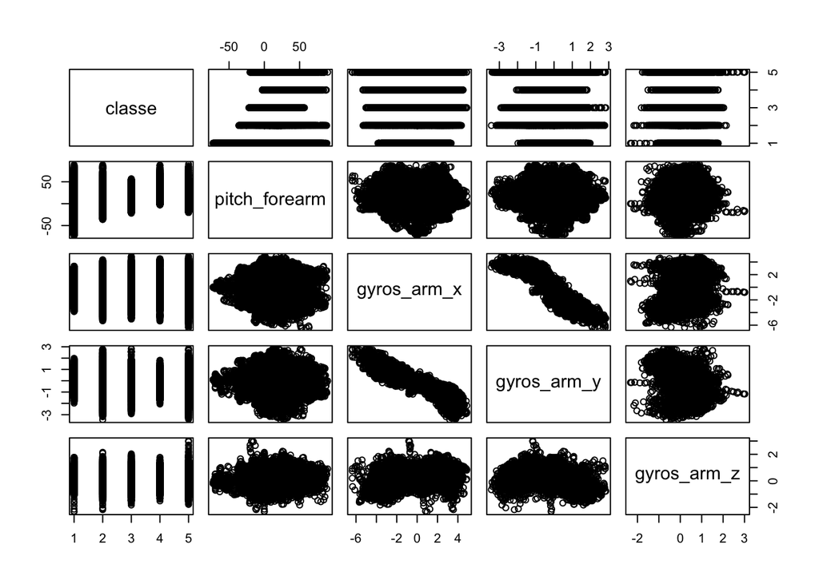

As a result, the raw data was removed.

Those columns which contained a very high number of NAs, and therefore very little variance, were also discarded.

# Models

```r
print(modFitRF)
```

```
## Random Forest
##
## 19622 samples
##    16 predictor
##     5 classes: 'A', 'B', 'C', 'D', 'E'
##
## No pre-processing
## Resampling: Bootstrapped (25 reps)
##
## Summary of sample sizes: 19622, 19622, 19622, 19622, 19622, 19622, ...
##
## Resampling results across tuning parameters:
##
##   mtry  Accuracy   Kappa      Accuracy SD  Kappa SD
##    2    0.9884941  0.9854435  0.001191729  0.001515032
##    9    0.9888492  0.9858935  0.001481374  0.001877974
##   16    0.9831147  0.9786411  0.002591125  0.003278019
##
## Accuracy was used to select the optimal model using  the largest value.
## The final value used for the model was mtry = 9.
```

[output not shown]

Values of the variable classe in the test data set are not available, but the model can be validated through a web site. Results from this submission report a 100% success rate.